# kNN (k-Nearest Neighbors) Relational analysis of Iris Width and Length

1. The dataset can be downloaded from UCI Machine Learning Repository: https://archive.ics.uci.edu/ml/machine-learning-databases/iris/.

**Data inspection.**

**Prepare the data for classification**.

**Split**

**Run the model fit**

**predict the class from features**

**number of neighbors `k`: 1, 3, 5, 7, 10, 20, 30, 40, and 50**:

```python
import pandas as pd
import matplotlib.pyplot as plt
import seaborn as sns
%matplotlib inline
import numpy as np
from sklearn.model_selection import train_test_split
from sklearn.neighbors import KNeighborsClassifier
import sklearn
```

```python
# Data download from sklearn
from sklearn.datasets import load_iris
data=load_iris().data
target=load_iris().target
df_data=pd.DataFrame(data,columns=['sepal_length','sepal_width','petal_length','petal_width'])
df_target=pd.DataFrame(target,columns=['target'])
```

```python
df = df_data
df['target']=df_target
df.head(5)
```

|  | sepal_length | sepal_width | petal_length | petal_width | target |
| --- | --- | --- | --- | --- | --- |
| 0 | 5.1 | 3.5 | 1.4 | 0.2 | 0 |
| 1 | 4.9 | 3.0 | 1.4 | 0.2 | 0 |
| 2 | 4.7 | 3.2 | 1.3 | 0.2 | 0 |
| 3 | 4.6 | 3.1 | 1.5 | 0.2 | 0 |
| 4 | 5.0 | 3.6 | 1.4 | 0.2 | 0 |

```python
df.describe()
```

|  | sepal_length | sepal_width | petal_length | petal_width | target |
| --- | --- | --- | --- | --- | --- |
| count | 150.000000 | 150.000000 | 150.000000 | 150.000000 | 150.000000 |
| mean | 5.843333 | 3.057333 | 3.758000 | 1.199333 | 1.000000 |
| std | 0.828066 | 0.435866 | 1.765298 | 0.762238 | 0.819232 |
| min | 4.300000 | 2.000000 | 1.000000 | 0.100000 | 0.000000 |
| 25% | 5.100000 | 2.800000 | 1.600000 | 0.300000 | 0.000000 |
| 50% | 5.800000 | 3.000000 | 4.350000 | 1.300000 | 1.000000 |
| 75% | 6.400000 | 3.300000 | 5.100000 | 1.800000 | 2.000000 |
| max | 7.900000 | 4.400000 | 6.900000 | 2.500000 | 2.000000 |

```python
df.isnull().sum()
```

```
sepal_length    0
sepal_width     0
petal_length    0
petal_width     0
target          0
dtype: int64
```

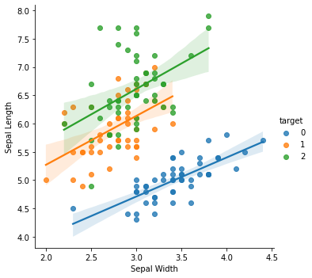

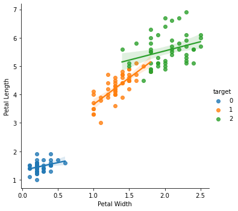

```python
sns.lmplot(x='sepal_width',y='sepal_length',
                data = df, hue = 'target')
plt.xlabel('Sepal Width')
plt.ylabel('Sepal Length')
plt.show()

sns.lmplot(x='petal_width',y='petal_length',
                data = df, hue = 'target')
plt.xlabel('Petal Width')
plt.ylabel('Petal Length')
plt.show()
```

```python
X = df[['sepal_length','sepal_width','petal_length','petal_width']]
Y = df['target']

X_array = np.array(X)
Y_array = np.array(Y)
Y_array.shape
```

```
(150,)
```

```python
X_train, X_test, Y_train, Y_test = sklearn.model_selection.train_test_split(X_array,Y_array, test_size=0.3)
print(X_train.shape)
print(X_test.shape)
print(Y_train.shape)
print(Y_test.shape)
```

```
(105, 4)
(45, 4)
(105,)
(45,)
```

```python
#Question 7:
neighbors = KNeighborsClassifier(n_neighbors=3)
neighbors.fit(X_train, Y_train)
```

```
KNeighborsClassifier(n_neighbors=3)
```

```python
# Question 8:
Y_pred = neighbors.predict(X_test)
print(Y_pred.shape)
Y_pred
```

```
(45,)
```

```
array([0, 2, 0, 1, 0, 2, 2, 0, 1, 0, 1, 2, 1, 2, 0, 1, 1, 2, 0, 0, 1, 2,
       2, 2, 2, 2, 0, 0, 0, 0, 2, 2, 1, 2, 1, 1, 2, 0, 0, 1, 0, 1, 1, 2,
       2])
```

```python
from sklearn.metrics import accuracy_score
#Accuracy score
print(accuracy_score(Y_pred,Y_test))
(Y_test == Y_pred)
```

```
0.9555555555555556
```

```
array([ True,  True,  True,  True,  True,  True,  True,  True,  True,
        True,  True,  True,  True,  True,  True,  True,  True,  True,
        True,  True,  True,  True,  True, False,  True,  True,  True,
        True,  True,  True, False,  True,  True,  True,  True,  True,
        True,  True,  True,  True,  True,  True,  True,  True,  True])
```

```python
k_values = [1, 3, 5, 7, 10, 20, 30, 40, 50]
average_accuracy=[]

for i in k_values:
    print(f'Number of Neighbors: {i}')
    for n in range(10):

        X_train, X_test, Y_train, Y_test = sklearn.model_selection.train_test_split(X_array,Y_array, test_size=0.3, random_state=None)
        neighbors = KNeighborsClassifier(n_neighbors=i)
        neighbors.fit(X_train, Y_train)
        Y_pred = neighbors.predict(X_test)
        print(f'Accuracy of the {i} Neighbors is: {accuracy_score(Y_pred,Y_test)}')
        average_accuracy.append(accuracy_score(Y_pred,Y_test))
```

```
Number of Neighbors: 1
Accuracy of the 1 Neighbors is: 0.9111111111111111
Accuracy of the 1 Neighbors is: 0.9555555555555556
Accuracy of the 1 Neighbors is: 0.9555555555555556
Accuracy of the 1 Neighbors is: 0.9333333333333333
Accuracy of the 1 Neighbors is: 0.9555555555555556
Accuracy of the 1 Neighbors is: 0.9777777777777777
Accuracy of the 1 Neighbors is: 0.9333333333333333
Accuracy of the 1 Neighbors is: 0.9777777777777777
Accuracy of the 1 Neighbors is: 0.9555555555555556
Accuracy of the 1 Neighbors is: 0.9777777777777777
Number of Neighbors: 3
Accuracy of the 3 Neighbors is: 0.9777777777777777
Accuracy of the 3 Neighbors is: 0.9777777777777777
Accuracy of the 3 Neighbors is: 0.9777777777777777
Accuracy of the 3 Neighbors is: 0.9333333333333333
Accuracy of the 3 Neighbors is: 0.9555555555555556
Accuracy of the 3 Neighbors is: 0.9777777777777777
Accuracy of the 3 Neighbors is: 0.9777777777777777
Accuracy of the 3 Neighbors is: 0.9555555555555556
Accuracy of the 3 Neighbors is: 0.9555555555555556
Accuracy of the 3 Neighbors is: 1.0
Number of Neighbors: 5
Accuracy of the 5 Neighbors is: 0.9777777777777777
Accuracy of the 5 Neighbors is: 0.9333333333333333
Accuracy of the 5 Neighbors is: 0.9777777777777777
Accuracy of the 5 Neighbors is: 0.9555555555555556
Accuracy of the 5 Neighbors is: 0.9777777777777777
Accuracy of the 5 Neighbors is: 0.9777777777777777
Accuracy of the 5 Neighbors is: 1.0
Accuracy of the 5 Neighbors is: 0.9777777777777777
Accuracy of the 5 Neighbors is: 0.9555555555555556
Accuracy of the 5 Neighbors is: 0.9777777777777777
Number of Neighbors: 7
Accuracy of the 7 Neighbors is: 0.9777777777777777
Accuracy of the 7 Neighbors is: 0.9555555555555556
Accuracy of the 7 Neighbors is: 0.9555555555555556
Accuracy of the 7 Neighbors is: 0.9555555555555556
Accuracy of the 7 Neighbors is: 0.9777777777777777
Accuracy of the 7 Neighbors is: 0.9777777777777777
```

[output cut: 44 more lines]

```
Accuracy of the 40 Neighbors is: 0.9777777777777777
Accuracy of the 40 Neighbors is: 0.8888888888888888
Accuracy of the 40 Neighbors is: 0.9111111111111111
Accuracy of the 40 Neighbors is: 0.8222222222222222
Number of Neighbors: 50
Accuracy of the 50 Neighbors is: 0.9555555555555556
Accuracy of the 50 Neighbors is: 0.9555555555555556
Accuracy of the 50 Neighbors is: 0.7555555555555555
Accuracy of the 50 Neighbors is: 0.9333333333333333
Accuracy of the 50 Neighbors is: 0.9111111111111111
Accuracy of the 50 Neighbors is: 0.8888888888888888
Accuracy of the 50 Neighbors is: 0.9111111111111111
Accuracy of the 50 Neighbors is: 0.9111111111111111
Accuracy of the 50 Neighbors is: 0.8666666666666667
Accuracy of the 50 Neighbors is: 0.8888888888888888
```

```python
k_1_average = np.mean(average_accuracy[:10])
k_3_average = np.mean(average_accuracy[10:20])
k_5_average = np.mean(average_accuracy[20:30])
k_7_average = np.mean(average_accuracy[30:40])
k_10_average = np.mean(average_accuracy[40:50])
k_20_average = np.mean(average_accuracy[50:60])
k_30_average = np.mean(average_accuracy[60:70])
k_40_average = np.mean(average_accuracy[70:80])
k_50_average = np.mean(average_accuracy[80:90])


accuracy_list = [k_1_average,k_3_average,k_5_average,k_7_average,k_10_average,k_20_average,k_30_average,
           k_40_average,k_50_average]
k = [1,3,5,7,10,20,30,40,50]
```

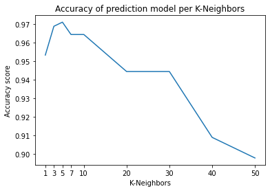

```python
plt.plot(k, accuracy_list)
plt.xlabel('K-Neighbors')
plt.ylabel('Accuracy score')
plt.xticks([1,3,5,7,10,20,30,40,50])
plt.title('Accuracy of prediction model per K-Neighbors')
```

## Accuracy of K conclusion

As can be seen from my graph as the number of K increases the less accurate the model becomes, the reason for it is because we are using a broader spectrum on our learning sample reaching for further examples in our training data set which might not be fully related. If our sample was larger this number would be further diluted. It is best to keep K at a lower range of numbers to maintain the accuracy of our predictions. However having K value too low will result in a lower accuracy as well as there are fewer neighbors chosen to train the predictions from, it is ideal to keep K at 3-5 to get the best results.